# 2025.11.16-Wallmart_Project_Q1

### Capstone Project - Walmart Dataset

```python
# Importing basic Libraries

import numpy as np
import pandas as pd
import matplotlib.pyplot as plt
import seaborn as sns
import math

import warnings
warnings.filterwarnings("ignore")
def fxn():
    warnings.warn("deprecated", DeprecationWarning)
with warnings.catch_warnings(action="ignore"):
    fxn()
```

```python
filepath = r'D:\Harpreet\Documents\Learning\Intellipaat- DS & AI 2025\ML\2025.11.16- Wallmart Project\Walmart_Dataset.csv'
walmart_df = pd.read_csv(filepath)
walmart_df
```

|  | Store | Date | Weekly_Sales | Holiday_Flag | Temperature | Fuel_Price | CPI | Unemployment |
| --- | --- | --- | --- | --- | --- | --- | --- | --- |
| 0 | 1 | 05-02-2010 | 1643690.90 | 0 | 42.31 | 2.572 | 211.096358 | 8.106 |
| 1 | 1 | 12-02-2010 | 1641957.44 | 1 | 38.51 | 2.548 | 211.242170 | 8.106 |
| 2 | 1 | 19-02-2010 | 1611968.17 | 0 | 39.93 | 2.514 | 211.289143 | 8.106 |
| 3 | 1 | 26-02-2010 | 1409727.59 | 0 | 46.63 | 2.561 | 211.319643 | 8.106 |
| 4 | 1 | 05-03-2010 | 1554806.68 | 0 | 46.50 | 2.625 | 211.350143 | 8.106 |
| ... | ... | ... | ... | ... | ... | ... | ... | ... |
| 6430 | 45 | 28-09-2012 | 713173.95 | 0 | 64.88 | 3.997 | 192.013558 | 8.684 |
| 6431 | 45 | 05-10-2012 | 733455.07 | 0 | 64.89 | 3.985 | 192.170412 | 8.667 |
| 6432 | 45 | 12-10-2012 | 734464.36 | 0 | 54.47 | 4.000 | 192.327265 | 8.667 |
| 6433 | 45 | 19-10-2012 | 718125.53 | 0 | 56.47 | 3.969 | 192.330854 | 8.667 |
| 6434 | 45 | 26-10-2012 | 760281.43 | 0 | 58.85 | 3.882 | 192.308899 | 8.667 |

6435 rows × 8 columns

**Observations**

- We have 45 stores. So to see performance of each store, we may need to take input of store number.
- It seems there is Temperature data also, indicating climatic conditions may be affecting the sales in some way.
- Weekly sales are given, there is a consistent span of 7 days of records. Weekly sales must be the amount of sales happened in that week span.
- CPI is the consumer price index, which indicates a ratio of consumption; sort of inflation factor. Probably indicating high CPI is high prices of Fuel.
- and parallelly, Uneployment rate may be a trend of records of the municipal.
- Probably the holiday flag may be that there might have been a holiday or more in the specific week

```python
# Firstly we get a date index to begin with

walmart_df['Date']= pd.to_datetime(walmart_df['Date'], errors='coerce', format="%d-%m-%Y")  # converts the Date object to datetime format
                                                                                            # included the format parameter to avoid errors moving forward
walmart_df.set_index("Date", inplace=True)     # make the Date column as the index
# walmart_df.sort_index(inplace=True, ascending=True)    # sort as per ascending order

walmart_df.info()
```

```
<class 'pandas.core.frame.DataFrame'>
DatetimeIndex: 6435 entries, 2010-02-05 to 2012-10-26
Data columns (total 7 columns):
 #   Column        Non-Null Count  Dtype
---  ------        --------------  -----
 0   Store         6435 non-null   int64
 1   Weekly_Sales  6435 non-null   float64
 2   Holiday_Flag  6435 non-null   int64
 3   Temperature   6435 non-null   float64
 4   Fuel_Price    6435 non-null   float64
 5   CPI           6435 non-null   float64
 6   Unemployment  6435 non-null   float64
dtypes: float64(5), int64(2)
memory usage: 402.2 KB
```

```python
walmart_df.head()
```

| Date | Store | Weekly_Sales | Holiday_Flag | Temperature | Fuel_Price | CPI | Unemployment |
| --- | --- | --- | --- | --- | --- | --- | --- |
| 2010-02-05 | 1 | 1643690.90 | 0 | 42.31 | 2.572 | 211.096358 | 8.106 |
| 2010-02-12 | 1 | 1641957.44 | 1 | 38.51 | 2.548 | 211.242170 | 8.106 |
| 2010-02-19 | 1 | 1611968.17 | 0 | 39.93 | 2.514 | 211.289143 | 8.106 |
| 2010-02-26 | 1 | 1409727.59 | 0 | 46.63 | 2.561 | 211.319643 | 8.106 |
| 2010-03-05 | 1 | 1554806.68 | 0 | 46.50 | 2.625 | 211.350143 | 8.106 |

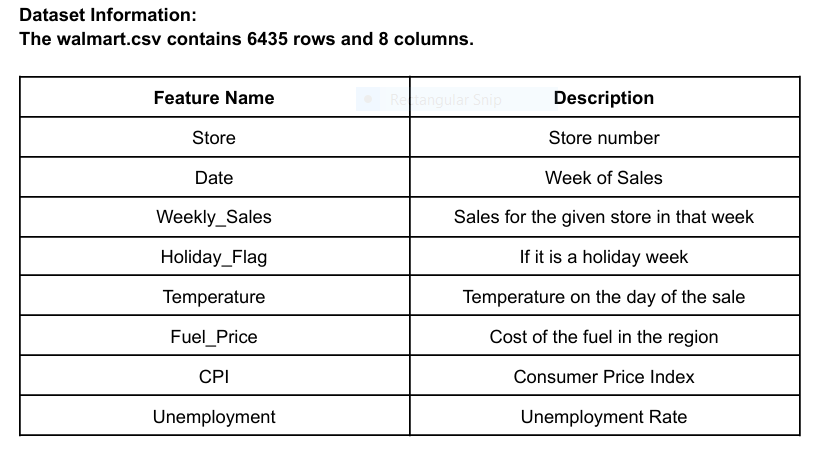

**1.** You are provided with the weekly sales data for their various outlets. Use statistical analysis, EDA, outlier analysis, and handle the missing values to come up with various insights that can give them a clear perspective on the following:

- a. If the weekly sales are affected by the unemployment rate, if yes - which stores are suffering the most?
- b. If the weekly sales show a seasonal trend, when and what could be the reason?
- c. Does temperature affect the weekly sales in any manner?
- d. How is the Consumer Price index affecting the weekly sales of various stores?
- e. Top performing stores according to the historical data.
- f. The worst performing store, and how significant is the difference between the highest and lowest performing stores.

**2.** Use predictive modeling techniques to forecast the sales for each store for the next 12 weeks.

#### Here we will solve the Q1 of the given project.

```python
# Checking for duplicates or Null values

print(f"Duplicate items = {walmart_df.duplicated().sum()}")
print("---------------------")
print(f"Null Items : \n{walmart_df.isnull().sum()}")
```

```
Duplicate items = 0
---------------------
Null Items :
Store           0
Weekly_Sales    0
Holiday_Flag    0
Temperature     0
Fuel_Price      0
CPI             0
Unemployment    0
dtype: int64
```

There aren't any duplicates or Nulls. We can proceed with the EDA

```python
number_of_stores= int(walmart_df['Store'].nunique())
stores= walmart_df['Store'].unique()
print(f'Dataset contains complete data from {number_of_stores} stores.')
```

```
Dataset contains complete data from 45 stores.
```

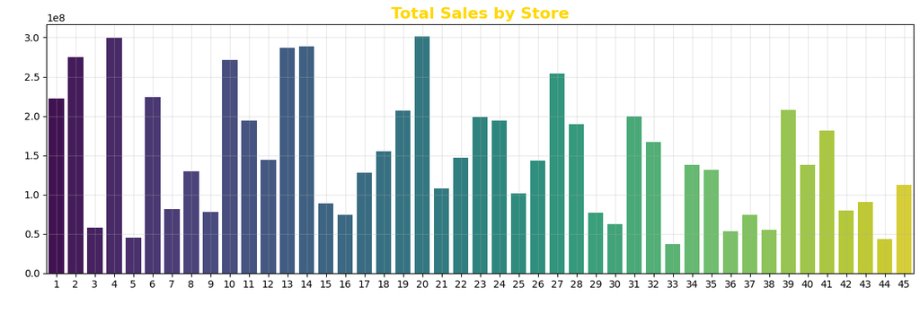

```python
plt.figure(figsize=(13,4.5))
store_sales = walmart_df.groupby('Store', as_index=False)['Weekly_Sales'].sum().sort_values(by='Weekly_Sales', ascending=False)

sns.barplot(
    data=store_sales,
    x='Store',
    y='Weekly_Sales',
    palette='viridis'
)

plt.title('Total Sales by Store', fontsize=16, color='gold', fontweight='semibold')
plt.xlabel('Store', fontsize=12, color='white')
plt.ylabel('Total Weekly Sales', fontsize=12, color='white')
plt.grid(alpha=0.3)
plt.tight_layout()
plt.show()
```

```python
correlation_matrix = walmart_df.corr()
correlation_matrix
```

|  | Store | Weekly_Sales | Holiday_Flag | Temperature | Fuel_Price | CPI | Unemployment |
| --- | --- | --- | --- | --- | --- | --- | --- |
| Store | 1.000000e+00 | -0.335332 | -4.386841e-16 | -0.022659 | 0.060023 | -0.209492 | 0.223531 |
| Weekly_Sales | -3.353320e-01 | 1.000000 | 3.689097e-02 | -0.063810 | 0.009464 | -0.072634 | -0.106176 |
| Holiday_Flag | -4.386841e-16 | 0.036891 | 1.000000e+00 | -0.155091 | -0.078347 | -0.002162 | 0.010960 |
| Temperature | -2.265908e-02 | -0.063810 | -1.550913e-01 | 1.000000 | 0.144982 | 0.176888 | 0.101158 |
| Fuel_Price | 6.002295e-02 | 0.009464 | -7.834652e-02 | 0.144982 | 1.000000 | -0.170642 | -0.034684 |
| CPI | -2.094919e-01 | -0.072634 | -2.162091e-03 | 0.176888 | -0.170642 | 1.000000 | -0.302020 |
| Unemployment | 2.235313e-01 | -0.106176 | 1.096028e-02 | 0.101158 | -0.034684 | -0.302020 | 1.000000 |

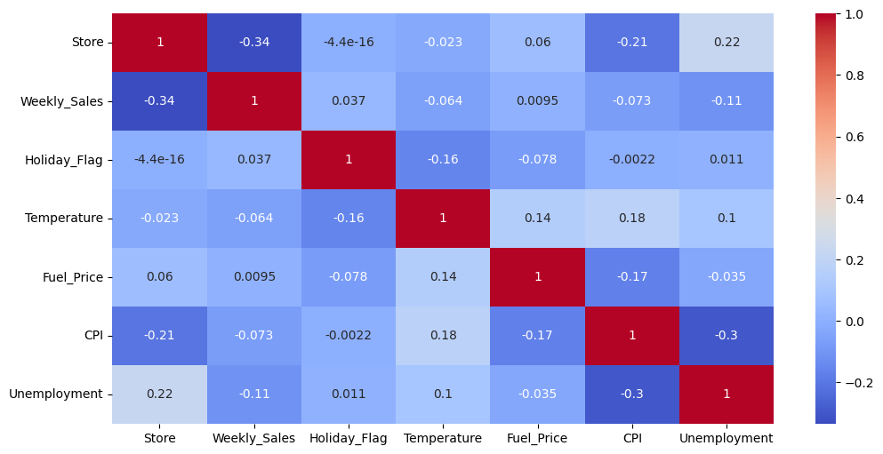

```python
plt.figure(figsize=(12, 6))
sns.heatmap(correlation_matrix, annot=True, cmap="coolwarm")
plt.show()
```

##### **1/a** ... If the weekly sales are affected by the unemployment rate, if yes - which stores are suffering the most?

```python
df= pd.DataFrame(walmart_df[['Store', 'Weekly_Sales', 'Unemployment']])
corr_matrix= df.corr()
corr_matrix
```

|  | Store | Weekly_Sales | Unemployment |
| --- | --- | --- | --- |
| Store | 1.000000 | -0.335332 | 0.223531 |
| Weekly_Sales | -0.335332 | 1.000000 | -0.106176 |
| Unemployment | 0.223531 | -0.106176 | 1.000000 |

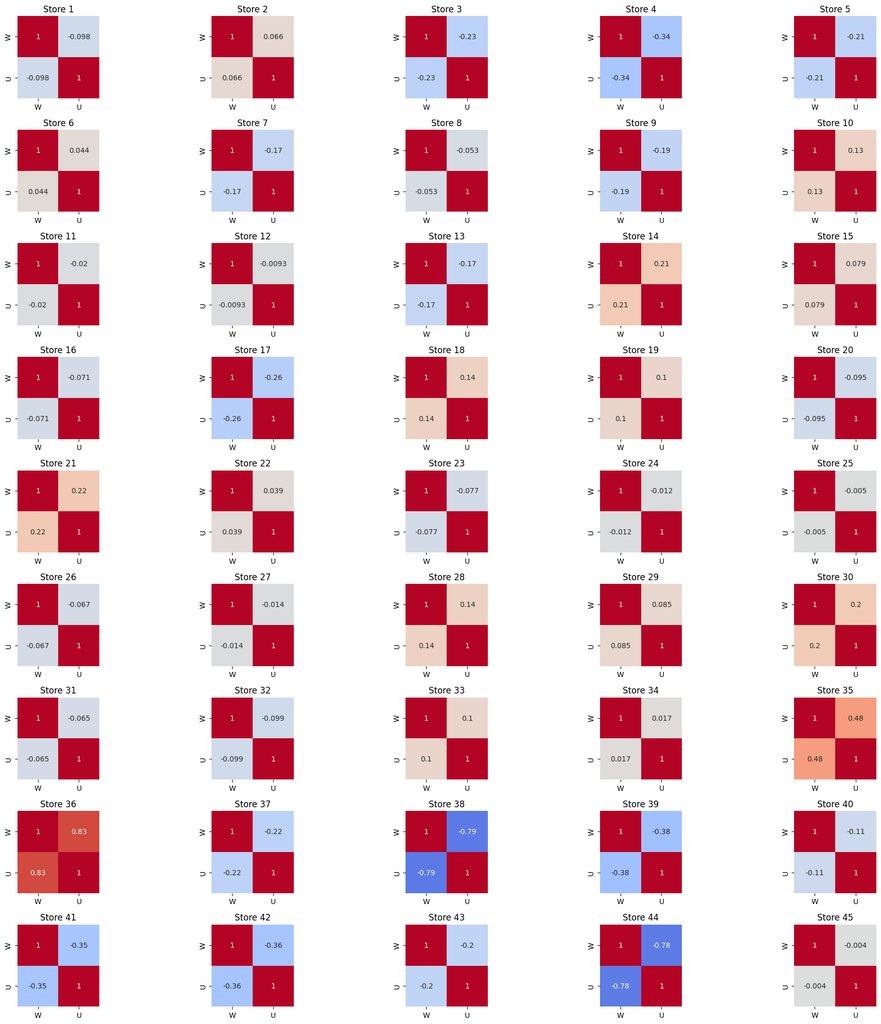

```python
# Generate and save a heatmap for each store

col_plots= 5
rows_plots= math.ceil(number_of_stores / col_plots)
fig, axes= plt.subplots(rows_plots, col_plots, figsize=(20,20))
axes= axes.flatten()

correlations= []

for i, store_no in enumerate(stores):
    store_data = df[df['Store'] == store_no][['Weekly_Sales', 'Unemployment']]
    store_data.rename(columns={'Weekly_Sales':'W', 'Unemployment':'U'}, inplace=True)
    corr_matrix = store_data.corr()

    corr_value= store_data['W'].corr(store_data['U'])
    correlations.append((store_no, corr_value))

    sns.heatmap(corr_matrix, annot=True, cmap='coolwarm', ax=axes[i], cbar=False, vmin=-1, vmax=1, square=True)
    axes[i].set_title(f'Store {store_no}')

for j in range (i+1, len(axes)):
    fig.delaxes(axes[j])

plt.tight_layout()
plt.show()
```

```python
# We will save the correlations in each store and sort it for further observations.
correlations_sorted= sorted(correlations, key=lambda x: x[1])

for store_id, corr in correlations_sorted:
    print(f"Store {store_id}: correlation = {corr:.4f}")
```

```
Store 38: correlation = -0.7853
Store 44: correlation = -0.7801
Store 39: correlation = -0.3847
Store 42: correlation = -0.3564
Store 41: correlation = -0.3506
Store 4: correlation = -0.3370
Store 17: correlation = -0.2636
Store 3: correlation = -0.2304
Store 37: correlation = -0.2213
Store 5: correlation = -0.2070
Store 43: correlation = -0.2020
Store 9: correlation = -0.1915
Store 13: correlation = -0.1716
Store 7: correlation = -0.1654
Store 40: correlation = -0.1125
Store 32: correlation = -0.0995
Store 1: correlation = -0.0980
Store 20: correlation = -0.0953
Store 23: correlation = -0.0772
Store 16: correlation = -0.0709
Store 26: correlation = -0.0669
Store 31: correlation = -0.0647
Store 8: correlation = -0.0526
Store 11: correlation = -0.0203
Store 27: correlation = -0.0143
Store 24: correlation = -0.0123
Store 12: correlation = -0.0093
Store 25: correlation = -0.0050
Store 45: correlation = -0.0040
Store 34: correlation = 0.0170
Store 22: correlation = 0.0390
Store 6: correlation = 0.0443
Store 2: correlation = 0.0663
Store 15: correlation = 0.0789
Store 29: correlation = 0.0847
Store 33: correlation = 0.1012
Store 19: correlation = 0.1015
Store 10: correlation = 0.1319
Store 28: correlation = 0.1367
Store 18: correlation = 0.1392
Store 30: correlation = 0.2019
Store 14: correlation = 0.2108
Store 21: correlation = 0.2184
Store 35: correlation = 0.4839
Store 36: correlation = 0.8337
```

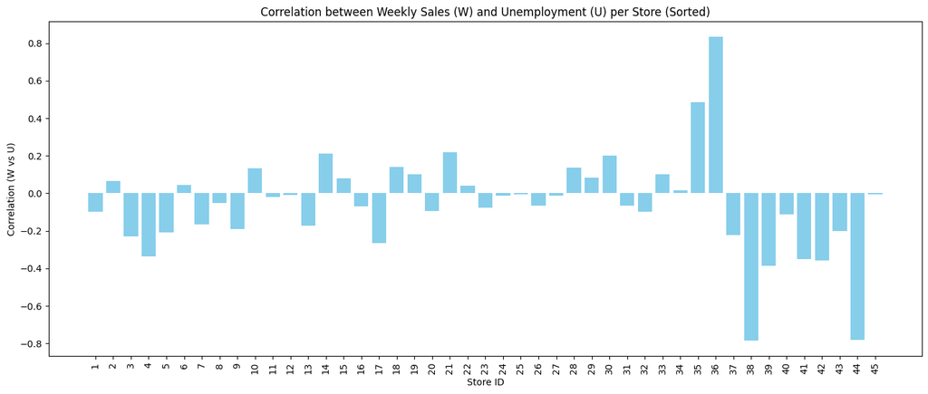

```python
# plotting a bar geraph of the correlations Values

corr_df= pd.DataFrame(correlations_sorted, columns=['Store_ID', 'Corr_Value'])
# Plotting
plt.figure(figsize=(14, 6))
bars = plt.bar(corr_df['Store_ID'], corr_df['Corr_Value'], color='skyblue')
plt.xlabel("Store ID")
plt.xticks(corr_df['Store_ID'], rotation=90)
plt.ylabel("Correlation (W vs U)")
plt.title("Correlation between Weekly Sales (W) and Unemployment (U) per Store (Sorted)")
plt.tight_layout()
plt.show()
```

The plot tells us that the impact of unemployment on weekly sales is store-specific. Some stores are resilient or even benefit when unemployment rises, while others are vulnerable.

##### **1/b** ... If the weekly sales show a seasonal trend, when and what could be the reason?

```python
walmart_df.head()
```

| Date | Store | Weekly_Sales | Holiday_Flag | Temperature | Fuel_Price | CPI | Unemployment |
| --- | --- | --- | --- | --- | --- | --- | --- |
| 2010-02-05 | 1 | 1643690.90 | 0 | 42.31 | 2.572 | 211.096358 | 8.106 |
| 2010-02-12 | 1 | 1641957.44 | 1 | 38.51 | 2.548 | 211.242170 | 8.106 |
| 2010-02-19 | 1 | 1611968.17 | 0 | 39.93 | 2.514 | 211.289143 | 8.106 |
| 2010-02-26 | 1 | 1409727.59 | 0 | 46.63 | 2.561 | 211.319643 | 8.106 |
| 2010-03-05 | 1 | 1554806.68 | 0 | 46.50 | 2.625 | 211.350143 | 8.106 |

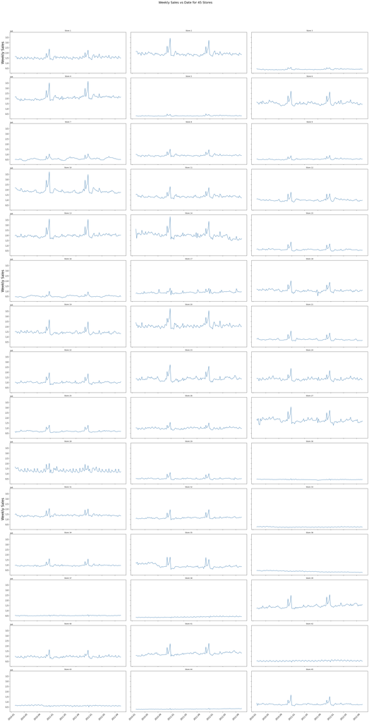

```python
df= pd.DataFrame(walmart_df, columns=['Store', "Weekly_Sales"])

fig, axes = plt.subplots(15, 3, figsize=(30,60), sharex=True, sharey=True)
axes = axes.flatten()

# Plot each store's data
for i, store in enumerate(sorted(df['Store'].unique())):
    ax = axes[i]
    store_data = df[df['Store'] == store]
    ax.plot(store_data.index, store_data['Weekly_Sales'], color='steelblue')
    ax.set_title(f'Store {store}', fontsize=10)
    ax.tick_params(axis='x', labelrotation=45, labelsize=12)
    ax.tick_params(axis='y', labelsize=12)
    if i % 15 == 0:
        ax.set_ylabel('Weekly Sales', fontsize=20)

# Hide any unused subplots
for j in range(len(stores), len(axes)):
    fig.delaxes(axes[j])

# Add main title and layout adjustments
fig.suptitle('Weekly Sales vs Date for 45 Stores', fontsize=18)
plt.tight_layout(rect=[0, 0, 1, 0.95])

plt.show()
```

A **Seasonal Trend** is observed almost around all the stores. There is a peak around Novem-December every year, perhaps becsuase of Christmas and Holidays. Some stores show very high peak of sales records, while some not as much. In some stores, there doesn't seem to be seasonality, perhaps because of cultural differences, or may be some other reasons not clear from the given dataset.

##### **1/c** ... Does temperature affect the weekly sales in any manner?

```python
walmart_df.head()
```

| Date | Store | Weekly_Sales | Holiday_Flag | Temperature | Fuel_Price | CPI | Unemployment |
| --- | --- | --- | --- | --- | --- | --- | --- |
| 2010-02-05 | 1 | 1643690.90 | 0 | 42.31 | 2.572 | 211.096358 | 8.106 |
| 2010-02-12 | 1 | 1641957.44 | 1 | 38.51 | 2.548 | 211.242170 | 8.106 |
| 2010-02-19 | 1 | 1611968.17 | 0 | 39.93 | 2.514 | 211.289143 | 8.106 |
| 2010-02-26 | 1 | 1409727.59 | 0 | 46.63 | 2.561 | 211.319643 | 8.106 |
| 2010-03-05 | 1 | 1554806.68 | 0 | 46.50 | 2.625 | 211.350143 | 8.106 |

```python
df= pd.DataFrame(walmart_df[['Store', 'Weekly_Sales', 'Temperature']])
corr_matrix= df.corr()
corr_matrix
```

|  | Store | Weekly_Sales | Temperature |
| --- | --- | --- | --- |
| Store | 1.000000 | -0.335332 | -0.022659 |
| Weekly_Sales | -0.335332 | 1.000000 | -0.063810 |
| Temperature | -0.022659 | -0.063810 | 1.000000 |

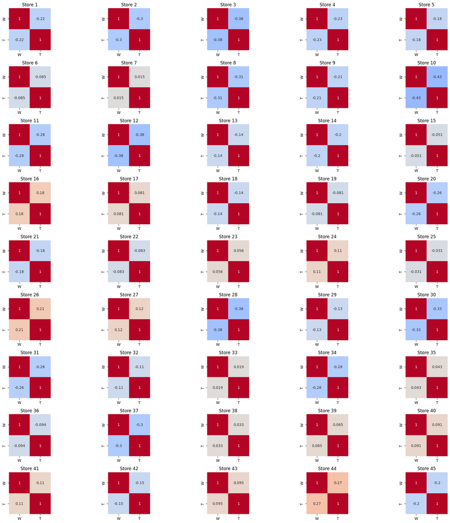

```python
# Generate and save a heatmap for each store

col_plots= 5
rows_plots= math.ceil(number_of_stores / col_plots)
fig, axes= plt.subplots(rows_plots, col_plots, figsize=(20,20))
axes= axes.flatten()

correlations= []

for i, store_no in enumerate(stores):
    store_data = df[df['Store'] == store_no][['Weekly_Sales', 'Temperature']]
    store_data.rename(columns={'Weekly_Sales':'W', 'Temperature':'T'}, inplace=True)
    corr_matrix = store_data.corr()

    corr_value= store_data['W'].corr(store_data['T'])
    correlations.append((store_no, corr_value))

    sns.heatmap(corr_matrix, annot=True, cmap='coolwarm', ax=axes[i], cbar=False, vmin=-1, vmax=1, square=True)
    axes[i].set_title(f'Store {store_no}')

for j in range (i+1, len(axes)):
    fig.delaxes(axes[j])

plt.tight_layout()
plt.show()
```

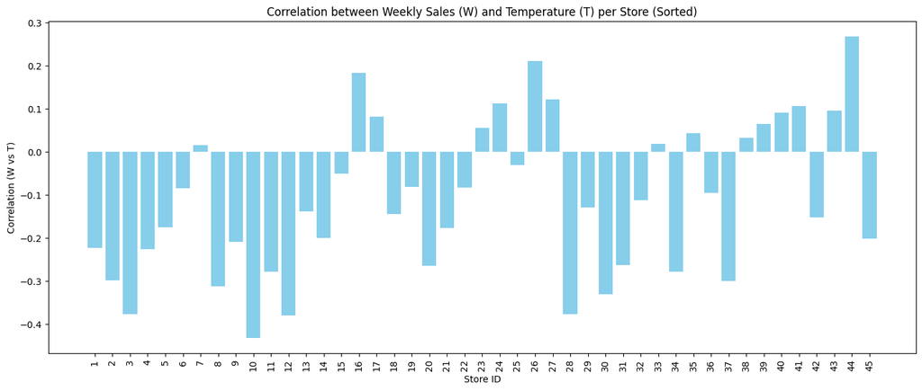

```python
corr_df= pd.DataFrame(correlations, columns=['Store_ID', 'Corr_Value'])
# Plotting
plt.figure(figsize=(14, 6))
bars = plt.bar(corr_df['Store_ID'], corr_df['Corr_Value'], color='skyblue')
plt.xlabel("Store ID")
plt.xticks(corr_df['Store_ID'], rotation=90)
plt.ylabel("Correlation (W vs T)")
plt.title("Correlation between Weekly Sales (W) and Temperature (T) per Store (Sorted)")
plt.tight_layout()
plt.show()
```

We can clearly see the trend that temperatures affect the weekly Sales given that **when the temperatures are lower, the sales are higher in most of the stores.** In some stores the trend is reverse, probably affected by other factors which are not clear from the given data set.

##### **1/d** ... How is the Consumer Price index affecting the weekly sales of various stores?

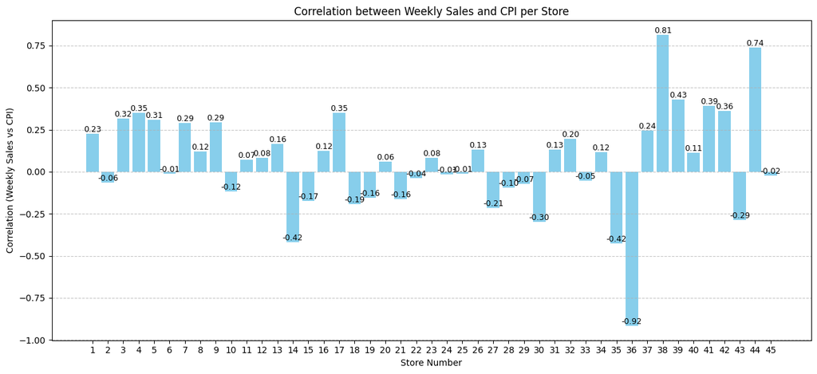

```python
# Creating bar graph of correlation between Weekly Sales and Unemployment per store
df= pd.DataFrame(walmart_df[['Store', 'Weekly_Sales', 'CPI']])

# Compute correlation per store
correlations = df.groupby("Store")[["Weekly_Sales", "CPI"]].corr().iloc[0::2,-1].reset_index()
correlations = correlations[["Store", "CPI"]].rename(columns={"CPI": "Corr_Value"})

# Plotting
plt.figure(figsize=(13, 6))
bars = plt.bar(correlations["Store"].astype(str), correlations["Corr_Value"], color='skyblue')
plt.xlabel("Store Number")
plt.ylabel("Correlation (Weekly Sales vs CPI)")
plt.title("Correlation between Weekly Sales and CPI per Store")
plt.grid(axis='y', linestyle='--', alpha=0.7)

# Annotate bars
for bar in bars:
    yval = bar.get_height()
    plt.text(bar.get_x() + bar.get_width()/2, yval, f"{yval:.2f}", ha='center', va='bottom', fontsize=9)

plt.tight_layout()
plt.show()
```

##### **1/e** ... Top performing stores according to the historical data.

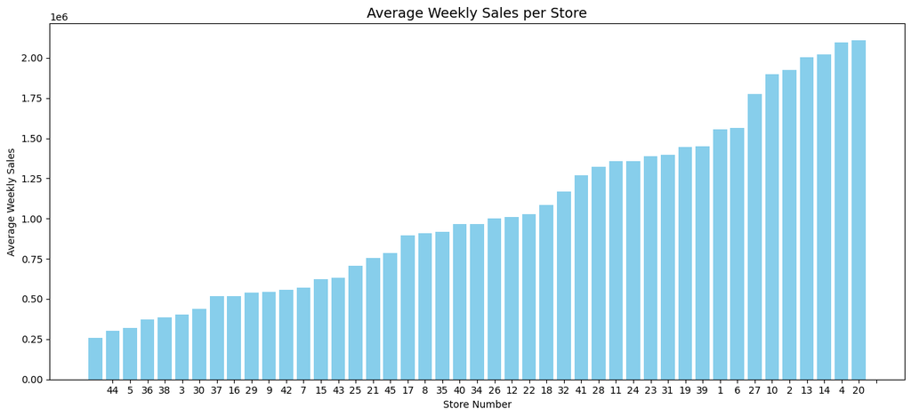

```python
# Best of Average Weekly Sales is performed by this store:
Avg_WeeklySales_StoreWise= pd.DataFrame(walmart_df.groupby('Store')['Weekly_Sales'].mean()).reset_index()
Avg_WeeklySales_StoreWise.sort_values(by='Weekly_Sales', ascending=True, inplace=True)

# Create bar plot
plt.figure(figsize=(13, 6))
plt.bar(Avg_WeeklySales_StoreWise['Store'].astype(str), Avg_WeeklySales_StoreWise['Weekly_Sales'], color='skyblue')
plt.xlabel('Store Number', fontsize=10)
plt.ylabel('Average Weekly Sales', fontsize=10)
plt.title('Average Weekly Sales per Store', fontsize=14)
plt.xticks(Avg_WeeklySales_StoreWise['Store'])
plt.tight_layout()
plt.show()
```

```python
# Maximum Weekly Sales is obtained by this store:

walmart_df[walmart_df['Weekly_Sales']== walmart_df['Weekly_Sales'].max()]
```

| Date | Store | Weekly_Sales | Holiday_Flag | Temperature | Fuel_Price | CPI | Unemployment |
| --- | --- | --- | --- | --- | --- | --- | --- |
| 2010-12-24 | 14 | 3818686.45 | 0 | 30.59 | 3.141 | 182.54459 | 8.724 |

##### **1/f** ... The worst performing store, and how significant is the difference between the highest and lowest performing stores.

```python
# Minimum Weekly Sales have bee registered by this store:

walmart_df[walmart_df['Weekly_Sales']== walmart_df['Weekly_Sales'].min()]
```

| Date | Store | Weekly_Sales | Holiday_Flag | Temperature | Fuel_Price | CPI | Unemployment |
| --- | --- | --- | --- | --- | --- | --- | --- |
| 2010-12-03 | 33 | 209986.25 | 0 | 52.82 | 3.041 | 126.731333 | 9.265 |

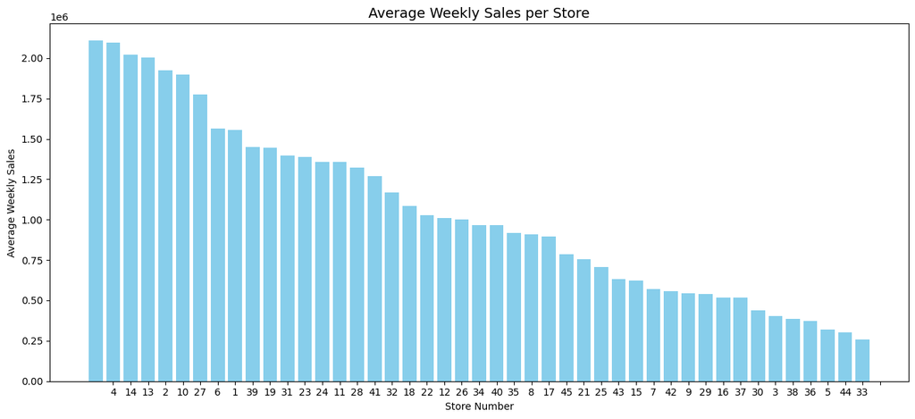

```python
# Worst Average Weekly sales are registered vby this store:

# Best of Average Weekly Sales is performed by this store:
Avg_WeeklySales_StoreWise= pd.DataFrame(walmart_df.groupby('Store')['Weekly_Sales'].mean()).reset_index()
Avg_WeeklySales_StoreWise.sort_values(by='Weekly_Sales', ascending=False, inplace=True)

# Create bar plot
plt.figure(figsize=(13, 6))
plt.bar(Avg_WeeklySales_StoreWise['Store'].astype(str), Avg_WeeklySales_StoreWise['Weekly_Sales'], color='skyblue')
plt.xlabel('Store Number', fontsize=10)
plt.ylabel('Average Weekly Sales', fontsize=10)
plt.title('Average Weekly Sales per Store', fontsize=14)
plt.xticks(Avg_WeeklySales_StoreWise['Store'])
plt.tight_layout()
plt.show()
```